# **Part B: Recurrent Neural Network (RNN)**

##### Name: Shaun Kwo Rui Yu Class: DAAA/FT/2A/03 Adm No.: 2317933

### **The main objective of this assignment is to:**

Build an appropriate deep neural network for analyzing movie reviews using the provided dataset. Consider preprocessing the data, choosing between regression or classification architectures, and deciding whether to include only English reviews or consider other languages as well.

### I am building a **classification RNN model for** `classifying sentiment of Movie Reviews` because **sentiment analysis typically involves discrete categories (positive, negative, neutral), making classification more suitable than regression.**

### **Research and Background**

- **RNNs in NLP:** Recurrent Neural Networks (RNNs) are commonly used for sequential data analysis tasks, including natural language processing (NLP) tasks like sentiment analysis.
- **Text Preprocessing:** Preprocessing steps like tokenization, stopword removal, and word embeddings are crucial for extracting meaningful features from text data.
- **Multilingual Analysis:** Consider the language diversity in the dataset and decide whether to focus solely on English reviews or include other languages for analysis.

### **EDA and Preprocessing**

- **Exploratory Data Analysis (EDA):** Explore the movie review dataset to understand sentiment label distributions, word frequencies, and potential preprocessing requirements.
- **Text Preprocessing:** Tokenize text, handle stopwords, and apply word embeddings (e.g., Word2Vec, GloVe) to represent words numerically for model input.

### **Model Architecture and Training**

- **RNN Architecture:** Choose appropriate RNN architectures such as Long Short-Term Memory (LSTM) or Gated Recurrent Unit (GRU) for sentiment analysis tasks.
- **Hyperparameter Tuning:** Optimize hyperparameters like sequence length, embedding dimensions, and RNN units to enhance model performance.
- **Language Consideration:** Decide whether to include multilingual analysis and justify this decision based on the dataset's language diversity.

### **Evaluation and Improvement**

- **Model Evaluation:** Evaluate the trained RNN models using validation metrics like accuracy, F1 score, or mean squared error (MSE) for regression tasks.
- **Model Improvement:** Experiment with different word embeddings, regularization techniques (e.g., dropout), and optimization strategies to improve model accuracy and generalization.

### Importing Libraries

```python
import re
import string
import numpy as np
import pandas as pd
import matplotlib.pyplot as plt
import seaborn as sns
from wordcloud import WordCloud

# Importing nltk libararies
import nlpaug
import nlpaug.augmenter.word as naw
from nltk.corpus import stopwords
from nltk.tokenize import word_tokenize
from nltk.stem import PorterStemmer, WordNetLemmatizer

# Importing Scikit-learn
from sklearn.model_selection import train_test_split
from sklearn.utils.class_weight import compute_class_weight
from sklearn.metrics import confusion_matrix


# Importing tensorflow and keras library
import tensorflow as tf
from keras.preprocessing.text import Tokenizer
from keras_preprocessing.sequence import pad_sequences
from keras.models import Sequential
from keras.layers import Embedding, LSTM, Dense, Dropout
from keras_tuner.tuners import RandomSearch
from keras.optimizers import Adam, RMSprop
from keras.callbacks import ModelCheckpoint, EarlyStopping
from keras.models import load_model
from keras_tuner.tuners import RandomSearch
from keras import regularizers
from keras.regularizers import l2

# Importing Gensim library to load Fasttext Malay embedding file
from gensim.models import KeyedVectors
```

### Importing Movie Review Dataset

```python
reviews=pd.read_csv('./Movie reviews.csv')

# Remove column
reviews=reviews.drop('Are there ways for you to generate more data? Spliting up sentences, would that help?', axis=1)
reviews
```

|  | Review | Score | Language |
| --- | --- | --- | --- |
| 0 | Filem ini hebat! Aksi yang mendebarkan dan plo... | 0.1 | Malay |
| 1 | Filem ini hebat! Aksi yang mendebarkan dan plo... | 0.9 | Malay |
| 2 | Filem ini hebat! Aksi yang mendebarkan dan plo... | 0.5 | Malay |
| 3 | Sayang sekali, pelakon tidak memberikan persem... | 0.8 | Malay |
| 4 | Jalan cerita yang kompleks dan penuh emosi. Su... | 0.2 | Malay |
| ... | ... | ... | ... |
| 522 | Pening | 0.7 | Malay |
| 523 | Berkesan | 0.2 | Malay |
| 524 | Mengujakan | 0.1 | Malay |
| 525 | Sederhana and teruk | 0.6 | Malay |
| 526 | Sempurna | 0.1 | Malay |

527 rows × 3 columns

```python
# Check for NaN values
nan_values = reviews.isna().sum()
print("NaN Values:\n------------------")
print(nan_values)

# Display rows with NaN values
rows_with_nan = reviews[reviews.isna().any(axis=1)]
print("\nRows with NaN Values:\n------------------")
print(rows_with_nan)

# Check for duplicated rows
duplicated_rows = reviews.duplicated().sum()
print("\nDuplicated Rows:\n------------------")
print(duplicated_rows)
```

```
NaN Values:
------------------
Review      0
Score       2
Language    0
dtype: int64

Rows with NaN Values:
------------------
       Review  Score Language
426    Ni hao    NaN  Chinese
493  Diabolic    NaN  English

Duplicated Rows:
------------------
111
```

#### Dropping Rows with Missing Values for Score

**Not accurate to estimate score** due to missing values.

#### Not Dropping Duplicated Rows

Duplicated rows may **affect statistical analyses**, such as calculating means, variances, or correlations

but assuming **the movie reviews are natural occurrences** in reviews written by different people.

**Natural occurrence**: Duplicates may highlight valuable information like recurring themes or popular opinions.

**More data is better**: Keeping duplicates can benefit model training and insights.

```python
# Drop rows with NaN values in the 'Score' column
reviews = reviews.dropna()

# Display the updated DataFrame
reviews
```

|  | Review | Score | Language |
| --- | --- | --- | --- |
| 0 | Filem ini hebat! Aksi yang mendebarkan dan plo... | 0.1 | Malay |
| 1 | Filem ini hebat! Aksi yang mendebarkan dan plo... | 0.9 | Malay |
| 2 | Filem ini hebat! Aksi yang mendebarkan dan plo... | 0.5 | Malay |
| 3 | Sayang sekali, pelakon tidak memberikan persem... | 0.8 | Malay |
| 4 | Jalan cerita yang kompleks dan penuh emosi. Su... | 0.2 | Malay |
| ... | ... | ... | ... |
| 522 | Pening | 0.7 | Malay |
| 523 | Berkesan | 0.2 | Malay |
| 524 | Mengujakan | 0.1 | Malay |
| 525 | Sederhana and teruk | 0.6 | Malay |
| 526 | Sempurna | 0.1 | Malay |

525 rows × 3 columns

```python
# Check data information
print('Movie Review Information:\n============================')
print(reviews.info())

# Summary statistics
print('\n\nMovie Review Statistic:\n============================')
print(reviews.describe())
```

```
Movie Review Information:
============================
<class 'pandas.core.frame.DataFrame'>
Index: 525 entries, 0 to 526
Data columns (total 3 columns):
 #   Column    Non-Null Count  Dtype
---  ------    --------------  -----
 0   Review    525 non-null    object
 1   Score     525 non-null    float64
 2   Language  525 non-null    object
dtypes: float64(1), object(2)
memory usage: 16.4+ KB
None


Movie Review Statistic:
============================
            Score
count  525.000000
mean     0.282626
std      0.263022
min      0.001000
25%      0.100000
50%      0.120000
75%      0.500000
max      0.997413
```

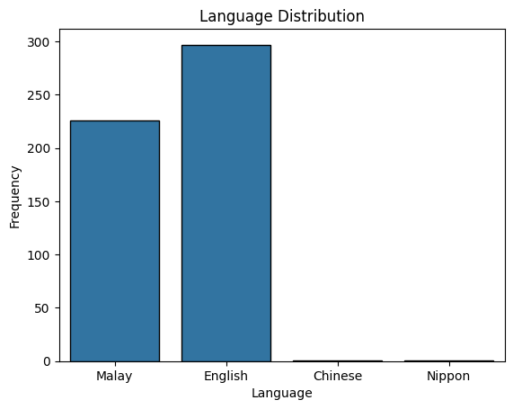

```python
# Assuming 'reviews' is your DataFrame containing the language data
sns.countplot(x='Language', data=reviews, edgecolor='black')
plt.xlabel('Language')
plt.ylabel('Frequency')
plt.title('Language Distribution')
plt.show()
```

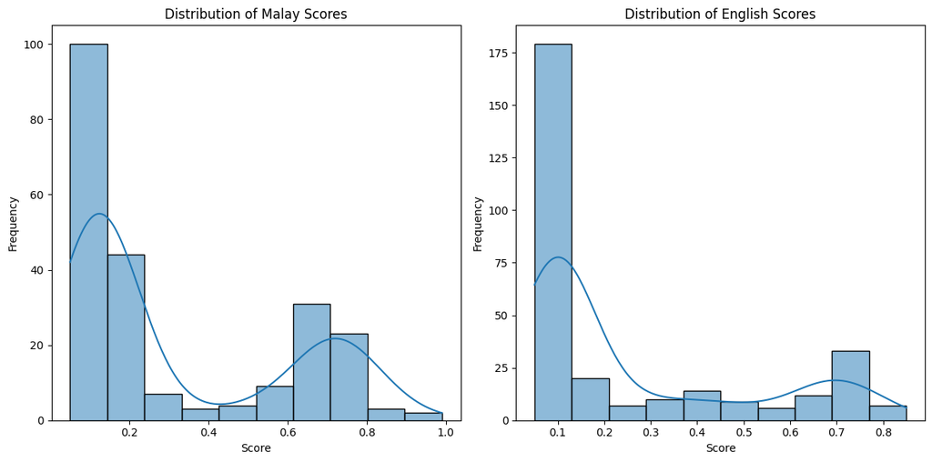

```python
# Create subplots for two visualizations
fig, axs = plt.subplots(1, 2, figsize=(12, 6))

# Distribution of scores for Malay language
sns.histplot(reviews[reviews['Language'] == 'Malay']['Score'], bins=10, kde=True, edgecolor='black', ax=axs[0])
axs[0].set_xlabel('Score')
axs[0].set_ylabel('Frequency')
axs[0].set_title('Distribution of Malay Scores')

# Distribution of scores for English language
sns.histplot(reviews[reviews['Language'] == 'English']['Score'], bins=10, kde=True, edgecolor='black', ax=axs[1])
axs[1].set_xlabel('Score')
axs[1].set_ylabel('Frequency')
axs[1].set_title('Distribution of English Scores')

# Adjust layout and display the plot
plt.tight_layout()
plt.show()
```

#### Observation:

From the **Score Distribution** graphs, it becomes evident that the distribution of Scores is **highly skewed towards the lower end, particularly within the range of 0 to 0.1.**

Hence, I would be trying to **create more data for between 0.1 to 1**

From the **Language Distribution** graph shows that there is a **significant amount of data for Malay and English**, whereas **Chinese and Nippon (Japanese) are notably sparse**, with very few data points, **almost zero.**

Hence, as there is not enough data to train RNN models with very little data, I would be dropping rows with `Language` of **Chinese and Nippon (Japanese)**.

As if any models are created **based on very little data**, the models are **very likely to be inaccurate and biased.**

```python
# Drop rows with 'Chinese' and 'Nippon' languages
reviews = reviews[(reviews['Language'] != 'Chinese') & (reviews['Language'] != 'Nippon')]

# Display the updated DataFrame
reviews
```

|  | Review | Score | Language |
| --- | --- | --- | --- |
| 0 | Filem ini hebat! Aksi yang mendebarkan dan plo... | 0.1 | Malay |
| 1 | Filem ini hebat! Aksi yang mendebarkan dan plo... | 0.9 | Malay |
| 2 | Filem ini hebat! Aksi yang mendebarkan dan plo... | 0.5 | Malay |
| 3 | Sayang sekali, pelakon tidak memberikan persem... | 0.8 | Malay |
| 4 | Jalan cerita yang kompleks dan penuh emosi. Su... | 0.2 | Malay |
| ... | ... | ... | ... |
| 522 | Pening | 0.7 | Malay |
| 523 | Berkesan | 0.2 | Malay |
| 524 | Mengujakan | 0.1 | Malay |
| 525 | Sederhana and teruk | 0.6 | Malay |
| 526 | Sempurna | 0.1 | Malay |

523 rows × 3 columns

### Data Preprocessing

##### Filtering and creating data for Score between 0.2-1 for English and Malay

```python
english_stopwords = set(stopwords.words('english'))


# Define the path to the Malay stopwords file
malay_stopwords_file = "./malay_stopwords.txt"

# Initialize an empty list to store the stopwords
malay_stopwords = []

# Open the file and read each line to extract stopwords
with open(malay_stopwords_file, 'r', encoding='utf-8') as file:
    for line in file:
        # Remove leading and trailing whitespace characters
        word = line.strip()
        malay_stopwords.append(word)

# Print the extracted Malay stopwords
print("Malay Stopwords:", malay_stopwords)
```

```
Malay Stopwords: ['ada', 'adakah', 'adakan', 'adalah', 'adanya', 'adapun', 'agak', 'agar', 'akan', 'aku', 'akulah', 'akupun', 'al', 'alangkah', 'allah', 'amat', 'antara', 'antaramu', 'antaranya', 'apa', 'apa-apa', 'apabila', 'apakah', 'apapun', 'atas', 'atasmu', 'atasnya', 'atau', 'ataukah', 'ataupu…
```

```python
# Function to preprocess text and generate new data
def preprocess_text(text):
    # Convert to lowercase
    text = text.lower()
    # Remove mentions
    text = re.sub("@\S+", " ", text)
    # Remove URL
    text = re.sub("https*\S+", " ", text)
    # Remove hashtags
    text = re.sub("#\S+", " ", text)
    # Remove all numbers
    text = re.sub("\d", " ", text)
    # Remove punctuations
    text = re.sub('[%s]' % re.escape(string.punctuation), ' ', text)
    # Remove extra spaces
    text = re.sub('\n', ' ', text)
    text = re.sub('\s{2,}', ' ', text)
    return text
# Cited from: https://www.kaggle.com/code/andriikolesnyk/rnn-for-text-classification

# Preprocess the 'Review' column
reviews['Review'] = reviews['Review'].apply(preprocess_text)

# Display the preprocessed data
reviews.head()
```

|  | Review | Score | Language |
| --- | --- | --- | --- |
| 0 | filem ini hebat aksi yang mendebarkan dan plot... | 0.1 | Malay |
| 1 | filem ini hebat aksi yang mendebarkan dan plot... | 0.9 | Malay |
| 2 | filem ini hebat aksi yang mendebarkan dan plot... | 0.5 | Malay |
| 3 | sayang sekali pelakon tidak memberikan persemb... | 0.8 | Malay |
| 4 | jalan cerita yang kompleks dan penuh emosi sun... | 0.2 | Malay |

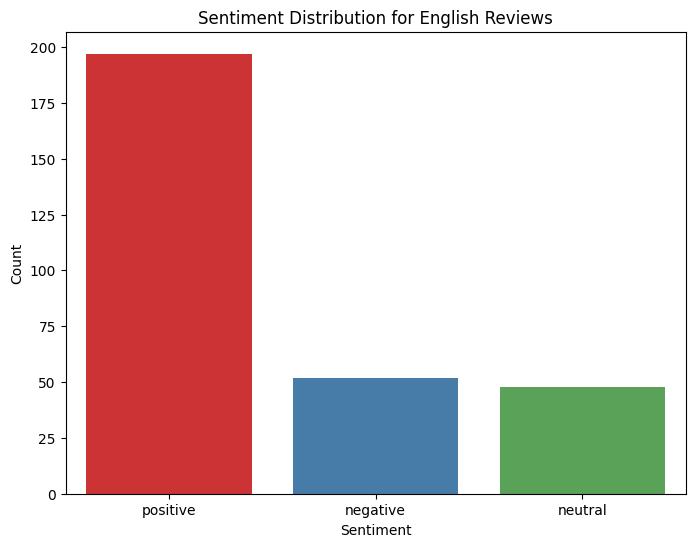

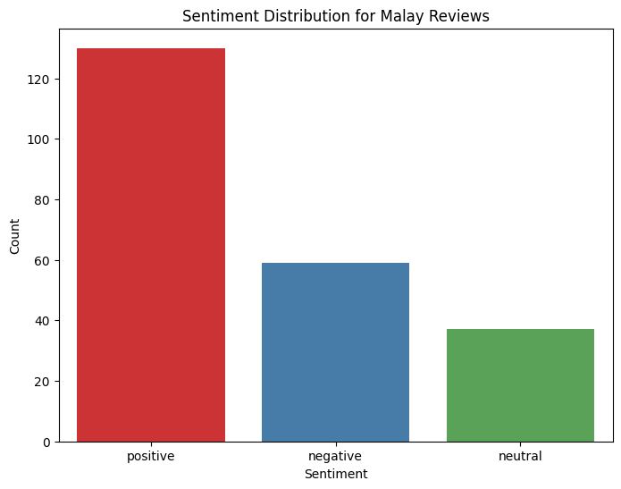

```python
# Define sentiment categories based on score
def get_sentiment(score):
    if score < 0.2:
        return 'positive'
    elif 0.2 <= score <= 0.6:
        return 'neutral'
    else:
        return 'negative'

# Apply the sentiment function to create a 'Sentiment' column
reviews['Sentiment'] = reviews['Score'].apply(get_sentiment)

# Separate reviews by language and sentiment
english_reviews = reviews[reviews['Language'] == 'English']
malay_reviews = reviews[reviews['Language'] == 'Malay']

# Plot sentiment distribution for English reviews
plt.figure(figsize=(8, 6))
sns.countplot(x='Sentiment', data=english_reviews, palette='Set1')
plt.title('Sentiment Distribution for English Reviews')
plt.xlabel('Sentiment')
plt.ylabel('Count')
plt.show()

# Plot sentiment distribution for Malay reviews
plt.figure(figsize=(8, 6))
sns.countplot(x='Sentiment', data=malay_reviews, palette='Set1')
plt.title('Sentiment Distribution for Malay Reviews')
plt.xlabel('Sentiment')
plt.ylabel('Count')
plt.show()
```

```python
# Initialize the synonym augmenter
aug = naw.SynonymAug(aug_src='wordnet')

# Function to augment data for a class
def augment_data(df_class, target_count):
    augmented_texts = []
    while len(df_class) + len(augmented_texts) < target_count:
        for _, row in df_class.iterrows():
            if len(df_class) + len(augmented_texts) >= target_count:
                break
            augmented_text = aug.augment(row['Review'])
            augmented_texts.append([augmented_text[0], row['Score'], row['Language'], row['Sentiment']])
    return pd.DataFrame(augmented_texts, columns=['Review', 'Score', 'Language', 'Sentiment'])

# Function to balance datasets by sentiment
def balance_datasets_by_sentiment(df, target_count):
    sentiments = ['positive', 'neutral', 'negative']
    balanced_df = pd.DataFrame(columns=['Review', 'Score', 'Language', 'Sentiment'])

    for sentiment in sentiments:
        df_sentiment = df[df['Sentiment'] == sentiment]
        if len(df_sentiment) < target_count:
            df_augmented = augment_data(df_sentiment, target_count)
            df_combined = pd.concat([df_sentiment, df_augmented])
        else:
            df_combined = df_sentiment.sample(target_count, random_state=88)
        balanced_df = pd.concat([balanced_df, df_combined])

    return balanced_df

# Set the target count for each sentiment
max_count = 200

# Balance the datasets for English reviews
english_balanced = balance_datasets_by_sentiment(english_reviews, max_count)

# Balance the datasets for Malay reviews
malay_balanced = balance_datasets_by_sentiment(malay_reviews, max_count)
```

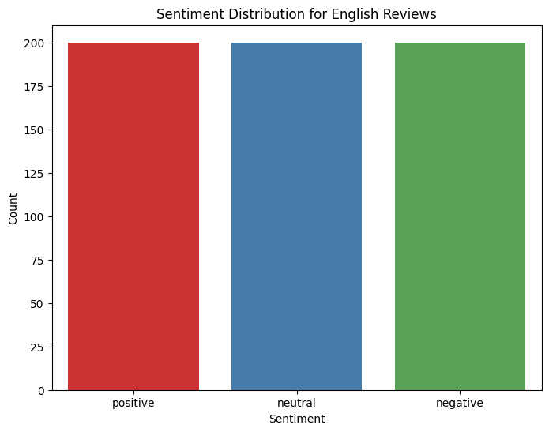

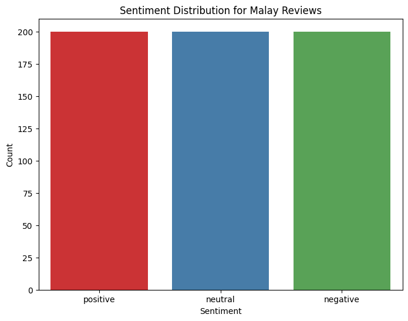

```python
# Plot sentiment distribution for English reviews
plt.figure(figsize=(8, 6))
sns.countplot(x='Sentiment', data=english_balanced, palette='Set1')
plt.title('Sentiment Distribution for English Reviews')
plt.xlabel('Sentiment')
plt.ylabel('Count')
plt.show()

# Plot sentiment distribution for Malay reviews
plt.figure(figsize=(8, 6))
sns.countplot(x='Sentiment', data=malay_balanced, palette='Set1')
plt.title('Sentiment Distribution for Malay Reviews')
plt.xlabel('Sentiment')
plt.ylabel('Count')
plt.show()
```

```python
english_balanced_negative_text = ' '.join(english_balanced[(english_balanced.Sentiment == 'negative') ]['Review'].tolist())
english_balanced_neutral_text = ' '.join(english_balanced[(english_balanced.Sentiment == 'neutral') ]['Review'].tolist())
english_balanced_positive_text = ' '.join(english_balanced[(english_balanced.Sentiment == 'positive') ]['Review'].tolist())
```

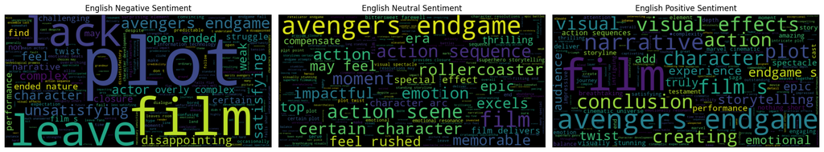

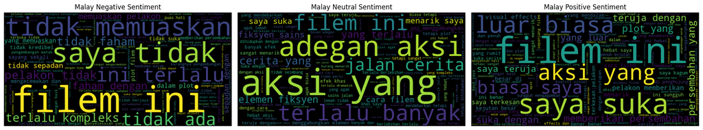

```python
from wordcloud import WordCloud
import matplotlib.pyplot as plt

# Separate the balanced reviews by language and sentiment
english_balanced_negative_text = ' '.join(english_balanced[(english_balanced.Sentiment == 'negative') ]['Review'].tolist())
english_balanced_neutral_text = ' '.join(english_balanced[(english_balanced.Sentiment == 'neutral') ]['Review'].tolist())
english_balanced_positive_text = ' '.join(english_balanced[(english_balanced.Sentiment == 'positive') ]['Review'].tolist())

malay_balanced_negative_text = ' '.join(malay_balanced[(malay_balanced.Sentiment == 'negative') ]['Review'].tolist())
malay_balanced_neutral_text = ' '.join(malay_balanced[(malay_balanced.Sentiment == 'neutral') ]['Review'].tolist())
malay_balanced_positive_text = ' '.join(malay_balanced[(malay_balanced.Sentiment == 'positive') ]['Review'].tolist())

# Define function to generate word cloud
def generate_wordcloud(text):
    return WordCloud(width=800, height=400, background_color='black').generate(text)

# Generate word clouds for the balanced datasets
english_negative_wordcloud = generate_wordcloud(english_balanced_negative_text)
english_neutral_wordcloud = generate_wordcloud(english_balanced_neutral_text)
english_positive_wordcloud = generate_wordcloud(english_balanced_positive_text)

malay_negative_wordcloud = generate_wordcloud(malay_balanced_negative_text)
malay_neutral_wordcloud = generate_wordcloud(malay_balanced_neutral_text)
malay_positive_wordcloud = generate_wordcloud(malay_balanced_positive_text)

# Plot the English word clouds
plt.figure(figsize=(18, 6))

plt.subplot(131)
plt.imshow(english_negative_wordcloud, interpolation='bilinear')
plt.title('English Negative Sentiment')
plt.axis('off')

plt.subplot(132)
plt.imshow(english_neutral_wordcloud, interpolation='bilinear')
plt.title('English Neutral Sentiment')
plt.axis('off')

plt.subplot(133)
plt.imshow(english_positive_wordcloud, interpolation='bilinear')
plt.title('English Positive Sentiment')
plt.axis('off')

plt.tight_layout()
plt.show()

# Plot the Malay word clouds
plt.figure(figsize=(18, 6))

plt.subplot(131)
plt.imshow(malay_negative_wordcloud, interpolation='bilinear')
plt.title('Malay Negative Sentiment')
plt.axis('off')

plt.subplot(132)
plt.imshow(malay_neutral_wordcloud, interpolation='bilinear')
plt.title('Malay Neutral Sentiment')
plt.axis('off')

plt.subplot(133)
plt.imshow(malay_positive_wordcloud, interpolation='bilinear')
plt.title('Malay Positive Sentiment')
plt.axis('off')

plt.tight_layout()
plt.show()
# Cited from: https://www.kaggle.com/code/andriikolesnyk/rnn-for-text-classification
```

### **Tokenization and Padding**

**convert the text into sequences of integers**

and pad them to a **maximum sequence length of 40**.

```python
# Tokenize the reviews
english_text = english_balanced['Review']
english_text = english_text.apply(word_tokenize)

MAX_SEQUENCE_LENGTH = 40

# Tokenize and pad sequences
english_tokenizer = Tokenizer()
english_tokenizer.fit_on_texts(english_text)
english_sequences = english_tokenizer.texts_to_sequences(english_text)

english_word_index = english_tokenizer.word_index
print('Found %s unique tokens.' % len(english_word_index))

english_data = pad_sequences(english_sequences, maxlen=MAX_SEQUENCE_LENGTH)
print("English data shape:", english_data.shape)
```

```
Found 1220 unique tokens.
English data shape: (600, 40)
```

```python
# Tokenize the reviews
malay_text = malay_balanced['Review']
malay_text = malay_text.apply(word_tokenize)

MAX_SEQUENCE_LENGTH = 40

# Tokenize and pad sequences
malay_tokenizer = Tokenizer()
malay_tokenizer.fit_on_texts(malay_text)
malay_sequences = malay_tokenizer.texts_to_sequences(malay_text)

malay_word_index = malay_tokenizer.word_index
print('Found %s unique tokens.' % len(malay_word_index))

malay_data = pad_sequences(malay_sequences, maxlen=MAX_SEQUENCE_LENGTH)
print("Malay data shape:", malay_data.shape)
```

```
Found 227 unique tokens.
Malay data shape: (600, 40)
```

### **Creating Embedding Matrix**

*Create an* *embedding matrix** based on the **GloVe and FastText embeddings**.*

GloVe file downloaded from: https://nlp.stanford.edu/projects/glove/ and https://fasttext.cc/docs/en/crawl-vectors.html

*.**Initialize it with zeros** and **fill in the embeddings for words** that exist in the vocabulary.*

```python
# Importing GloVe embedding file
path_to_glove_file = './glove.6B.100d.txt'

embeddings_index = {}
with open(path_to_glove_file, encoding='utf-8') as f:
    for line in f:
        values = line.split()
        word = values[0]
        coefs = np.asarray(values[1:], dtype='float32')
        embeddings_index[word] = coefs

print('Found %s word vectors.' % len(embeddings_index))

english_embedding_dim = 100

# Create embedding matrix for English dataset
english_embedding_matrix = np.zeros((len(english_word_index) + 1, english_embedding_dim))
print(english_word_index)


for word, i in english_word_index.items():
    embedding_vector = embeddings_index.get(word)
    if embedding_vector is not None:
        english_embedding_matrix[i] = embedding_vector

print("English embedding matrix shape:", english_embedding_matrix.shape)
# Cited from: https://www.kaggle.com/code/andriikolesnyk/rnn-for-text-classification
```

```
Found 400000 word vectors.
{'the': 1, 'a': 2, 'of': 3, 'to': 4, 'and': 5, 'film': 6, 'endgame': 7, 'plot': 8, 'in': 9, 'action': 10, 'avengers': 11, 'is': 12, 'while': 13, 'with': 14, 's': 15, 'this': 16, 'character': 17, 'some': 18, 'i': 19, 'emotional': 20, 'that': 21, 'are': 22, 'visual': 23, 'narrative': 24, 'an': 25, 'ef…
English embedding matrix shape: (1221, 100)
```

```python
# Path to your embeddings file
embeddings_path = './cc.ms.300.vec'

# Load the embeddings using KeyedVectors
fastText = KeyedVectors.load_word2vec_format(embeddings_path)

malay_embedding_dim = 300

# Create embedding matrix for Malay dataset
malay_embedding_matrix = np.zeros((len(malay_word_index) + 1, malay_embedding_dim))
print(malay_word_index)

for word, i in malay_word_index.items():
    if word in fastText:
        embedding_vector = fastText[word]
        malay_embedding_matrix[i] = embedding_vector

print("Malay embedding matrix shape:", malay_embedding_matrix.shape)
```

```
{'yang': 1, 'saya': 2, 'filem': 3, 'ini': 4, 'tidak': 5, 'dengan': 6, 'terlalu': 7, 'aksi': 8, 'suka': 9, 'dan': 10, 'plot': 11, 'sangat': 12, 'menarik': 13, 'memuaskan': 14, 'pelakon': 15, 'tetapi': 16, 'cerita': 17, 'banyak': 18, 'biasa': 19, 'adegan': 20, 'elemen': 21, 'hebat': 22, 'cara': 23, 'j…
Malay embedding matrix shape: (228, 300)
```

### **Splitting Data and Preparing Labels**

Now, let's **split the data into training and test sets** and **prepare the labels.**

```python
english_balanced
```

|  | Review | Score | Language | Sentiment |
| --- | --- | --- | --- | --- |
| 206 | this movie is amazing the action is breathtaki... | 0.08 | English | positive |
| 208 | the storyline is touching and full of emotion ... | 0.12 | English | positive |
| 209 | this movie delivers an outstanding experience ... | 0.05 | English | positive |
| 211 | i m thrilled throughout the movie engaging sto... | 0.15 | English | positive |
| 214 | this film is truly impressive with deep emotio... | 0.12 | English | positive |
| ... | ... | ... | ... | ... |
| 143 | overlook | 0.75 | English | negative |
| 144 | whirl | 0.70 | English | negative |
| 145 | average | 0.65 | English | negative |
| 146 | unconvincing | 0.75 | English | negative |
| 147 | flat story | 0.65 | English | negative |

600 rows × 4 columns

```python
labels_dict = {'positive': 2, 'negative': 0, 'neutral': 1}
y_final = english_balanced['Sentiment'].map(labels_dict)

# Split the data into training and test sets (small caps for EL: x, y)
x_train, x_test, y_train, y_test = train_test_split(english_data, y_final, test_size=0.2, random_state=42)
print("English Training data shape:", x_train.shape)
print("English Testing data shape:", x_test.shape)
```

```
English Training data shape: (480, 40)
English Testing data shape: (120, 40)
```

```python
y_final = malay_balanced['Sentiment'].map(labels_dict)

# Split the data into training and test sets (Large caps for EL: x, y)
X_train, X_test, Y_train, Y_test = train_test_split(malay_data, y_final, test_size=0.2, random_state=42)
print("Malay training data shape:", X_train.shape)
print("Malay testing data shape:", X_test.shape)
```

```
Malay training data shape: (480, 40)
Malay testing data shape: (120, 40)
```

```python
num_classes=3
```

### Confusion Matrix Plot Function

```python
# Function to plot confusion matrix
def plot_confusion_matrix(cm, class_names):
    plt.figure(figsize=(10, 7))
    sns.heatmap(cm, annot=True, fmt="d", cmap='Blues', xticklabels=class_labels, yticklabels=class_labels)
    plt.title('Confusion Matrix')
    plt.ylabel('True Label')
    plt.xlabel('Predicted Label')
    plt.show()
```

### **Building and Training the Model**

Building and training the LSTM model using Keras

My model consists of:

- 1 Embedding input layer
- 1 LSTM layer
- 1 Dense layer

[output not shown]

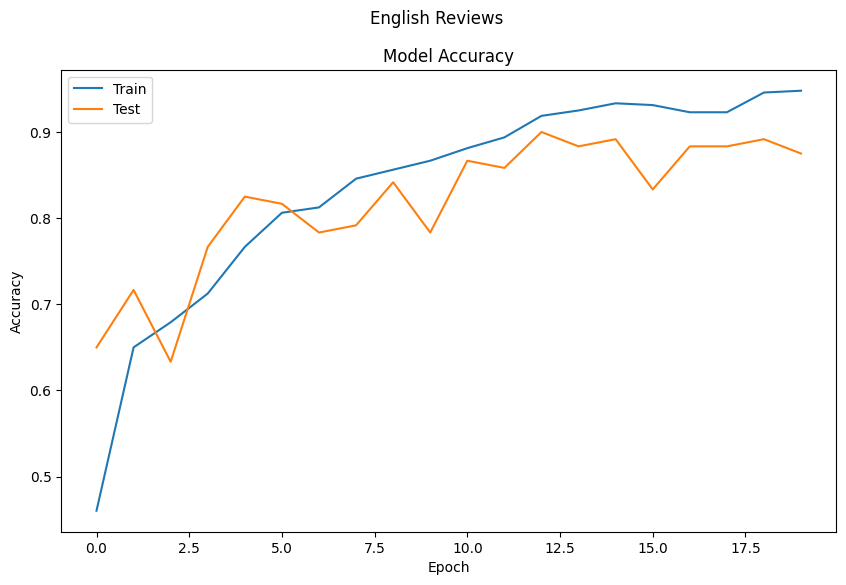

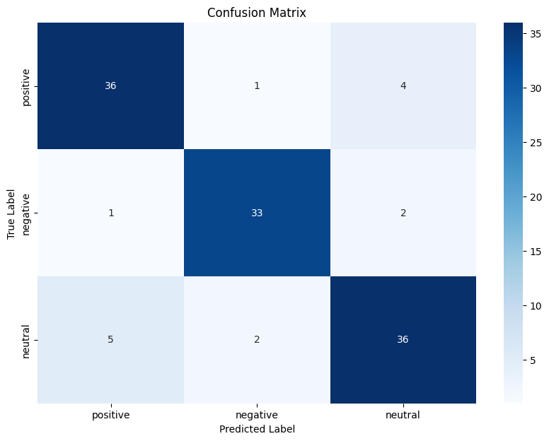

```
Test Accuracy: 0.8750
Error Rate: 0.1250
```

```python
# Set the seed for reproducibility
seed = 88
np.random.seed(seed)
tf.random.set_seed(seed)

num_classes=3

# Creating baseline model
model = Sequential()
model.add(Embedding(len(english_word_index) + 1, english_embedding_dim, input_length=MAX_SEQUENCE_LENGTH, weights=[english_embedding_matrix], trainable=False))
model.add(LSTM(100, dropout=0.2, recurrent_dropout=0.2))
model.add(Dense(num_classes, activation='softmax'))

model.compile(loss='sparse_categorical_crossentropy', optimizer='adam', metrics=['accuracy'])
model.summary()

history=model.fit(x_train, y_train, epochs=20, batch_size=64, validation_data=(x_test,y_test))

# Plot accuracy
plt.figure(figsize=(10, 6))
plt.suptitle('English Reviews')
plt.plot(history.history['accuracy'], label='Train')
plt.plot(history.history['val_accuracy'], label='Test')
plt.title('Model Accuracy')
plt.ylabel('Accuracy')
plt.xlabel('Epoch')
plt.legend(loc='upper left')
plt.show()

# Predict the output on the test set
predictions = model.predict(x_test)
predicted_classes = np.argmax(predictions, axis=1)

# Get the true labels
true_classes = y_test

class_labels=labels_dict.keys()

# Compute the confusion matrix
cm = confusion_matrix(true_classes, predicted_classes)

# Plot confusion matrix
plot_confusion_matrix(cm, class_labels)

# Evaluate the model on the test set
test_loss, test_accuracy = model.evaluate(x_test, y_test)

# Print the test accuracy and error rate
print(f'Test Accuracy: {test_accuracy:.4f}')
print(f'Error Rate: {(1 - test_accuracy):.4f}')
```

[output not shown]

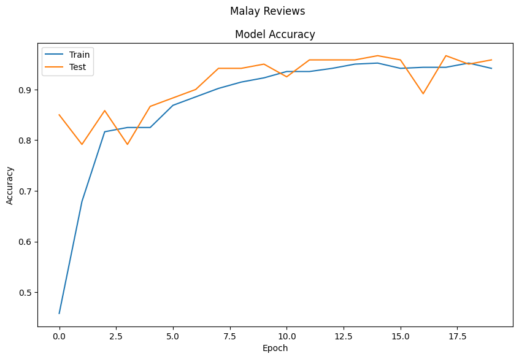

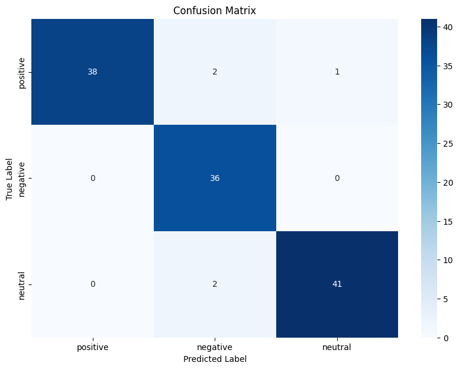

```
Test Accuracy: 0.9583
Error Rate: 0.0417
```

```python
# Set the seed for reproducibility
seed = 88
np.random.seed(seed)
tf.random.set_seed(seed)

# Creating baseline model
model = Sequential()
model.add(Embedding(len(malay_word_index) + 1, malay_embedding_dim, input_length=MAX_SEQUENCE_LENGTH, weights=[malay_embedding_matrix], trainable=False))
model.add(LSTM(300, dropout=0.2, recurrent_dropout=0.2))
model.add(Dense(3, activation='softmax'))

model.compile(loss='sparse_categorical_crossentropy', optimizer='adam', metrics=['accuracy'])
model.summary()

history=model.fit(X_train, Y_train, epochs=20, batch_size=64, validation_data=(X_test,Y_test))

# Plot accuracy
plt.figure(figsize=(10, 6))
plt.suptitle('Malay Reviews')
plt.plot(history.history['accuracy'], label='Train')
plt.plot(history.history['val_accuracy'], label='Test')
plt.title('Model Accuracy')
plt.ylabel('Accuracy')
plt.xlabel('Epoch')
plt.legend(loc='upper left')
plt.show()

# Predict the output on the test set
predictions = model.predict(X_test)
predicted_classes = np.argmax(predictions, axis=1)

# Get the true labels
true_classes = Y_test

class_labels=labels_dict.keys()

# Compute the confusion matrix
cm = confusion_matrix(true_classes, predicted_classes)

# Plot confusion matrix
plot_confusion_matrix(cm, class_labels)

# Evaluate the model on the test set
test_loss, test_accuracy = model.evaluate(X_test, Y_test)

# Print the test accuracy and error rate
print(f'Test Accuracy: {test_accuracy:.4f}')
print(f'Error Rate: {(1 - test_accuracy):.4f}')
```

### **Increasing Epochs from 20 to 100**

[output not shown]

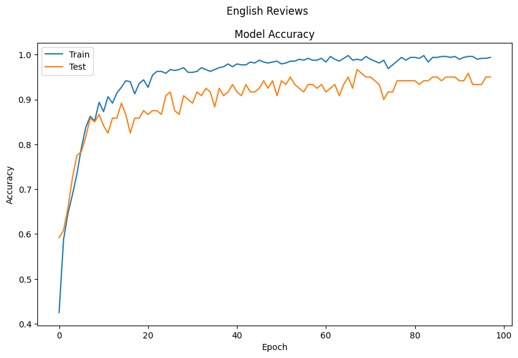

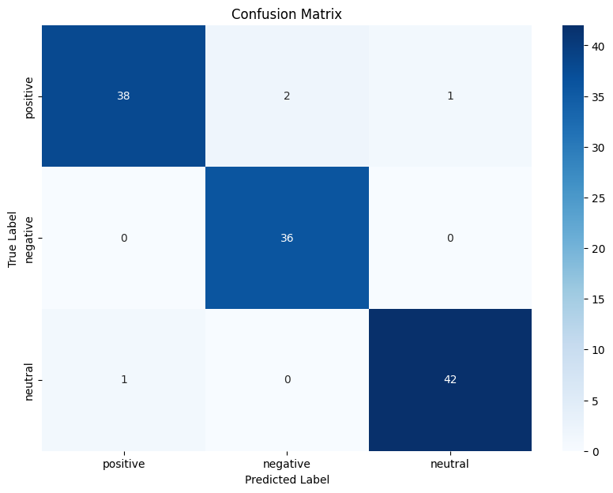

```
Test Accuracy: 0.9667
Error Rate: 0.0333
```

```python
# Set the seed for reproducibility
seed = 88
np.random.seed(seed)
tf.random.set_seed(seed)

num_classes=3

# Creating baseline model
model = Sequential()
model.add(Embedding(len(english_word_index) + 1, english_embedding_dim, input_length=MAX_SEQUENCE_LENGTH, weights=[english_embedding_matrix], trainable=False))
model.add(LSTM(100, dropout=0.2, recurrent_dropout=0.2))
model.add(Dense(num_classes, activation='softmax'))

model.compile(loss='sparse_categorical_crossentropy', optimizer='adam', metrics=['accuracy'])
model.summary()

# Define early stopping callback
early_stopping = EarlyStopping(monitor='val_accuracy', patience=30, verbose=2, restore_best_weights=True)

history=model.fit(x_train, y_train, epochs=100, batch_size=64, validation_data=(x_test,y_test), callbacks=[early_stopping])

# Plot accuracy
plt.figure(figsize=(10, 6))
plt.suptitle('English Reviews')
plt.plot(history.history['accuracy'], label='Train')
plt.plot(history.history['val_accuracy'], label='Test')
plt.title('Model Accuracy')
plt.ylabel('Accuracy')
plt.xlabel('Epoch')
plt.legend(loc='upper left')
plt.show()

# Predict the output on the test set
predictions = model.predict(x_test)
predicted_classes = np.argmax(predictions, axis=1)

# Get the true labels
true_classes = y_test

class_labels=labels_dict.keys()

# Compute the confusion matrix
cm = confusion_matrix(true_classes, predicted_classes)

# Plot confusion matrix
plot_confusion_matrix(cm, class_labels)

# Evaluate the model on the test set
test_loss, test_accuracy = model.evaluate(x_test, y_test)

# Print the test accuracy and error rate
print(f'Test Accuracy: {test_accuracy:.4f}')
print(f'Error Rate: {(1 - test_accuracy):.4f}')
```

[output not shown]

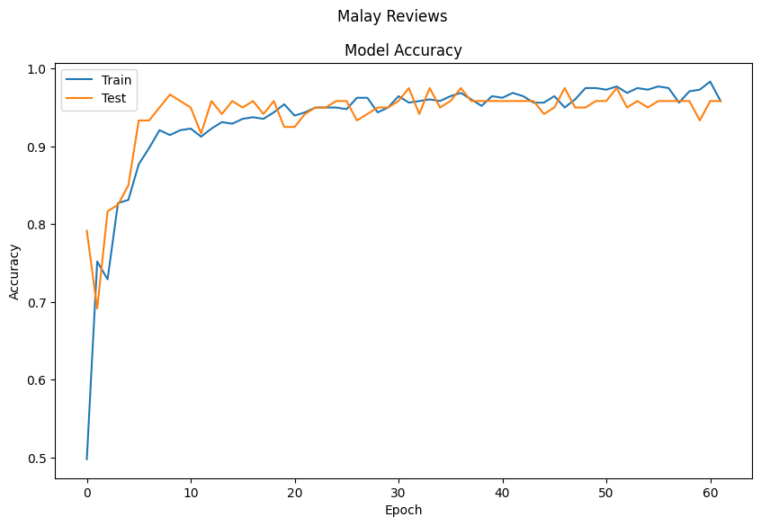

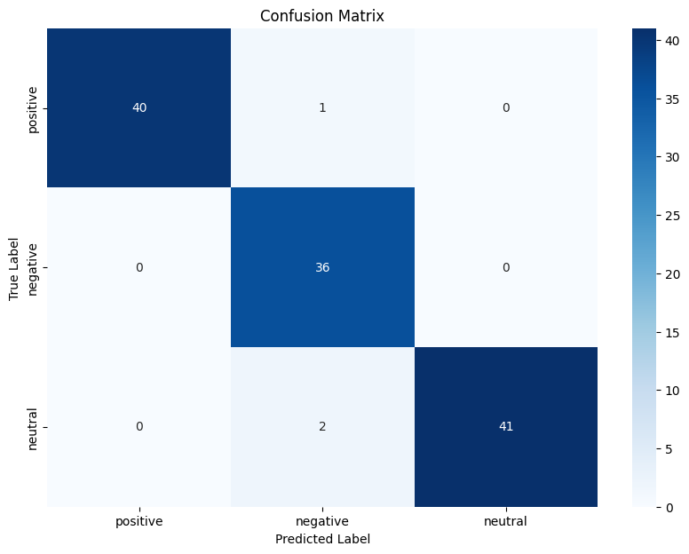

```
Test Accuracy: 0.9750
Error Rate: 0.0250
```

```python
# Set the seed for reproducibility
seed = 88
np.random.seed(seed)
tf.random.set_seed(seed)

# Creating baseline model
model = Sequential()
model.add(Embedding(len(malay_word_index) + 1, malay_embedding_dim, input_length=MAX_SEQUENCE_LENGTH, weights=[malay_embedding_matrix], trainable=False))
model.add(LSTM(300, dropout=0.2, recurrent_dropout=0.2))
model.add(Dense(3, activation='softmax'))

model.compile(loss='sparse_categorical_crossentropy', optimizer='adam', metrics=['accuracy'])
model.summary()

history=model.fit(X_train, Y_train, epochs=100, batch_size=64, validation_data=(X_test,Y_test),callbacks=[early_stopping])

# Plot accuracy
plt.figure(figsize=(10, 6))
plt.suptitle('Malay Reviews')
plt.plot(history.history['accuracy'], label='Train')
plt.plot(history.history['val_accuracy'], label='Test')
plt.title('Model Accuracy')
plt.ylabel('Accuracy')
plt.xlabel('Epoch')
plt.legend(loc='upper left')
plt.show()

# Predict the output on the test set
predictions = model.predict(X_test)
predicted_classes = np.argmax(predictions, axis=1)

# Get the true labels
true_classes = Y_test

class_labels=labels_dict.keys()

# Compute the confusion matrix
cm = confusion_matrix(true_classes, predicted_classes)

# Plot confusion matrix
plot_confusion_matrix(cm, class_labels)

# Evaluate the model on the test set
test_loss, test_accuracy = model.evaluate(X_test, Y_test)

# Print the test accuracy and error rate
print(f'Test Accuracy: {test_accuracy:.4f}')
print(f'Error Rate: {(1 - test_accuracy):.4f}')
```

### **Model Improvement**

My improved model consists of:

- 1 Embedding input layer
- 2 LSTM layer
- 2 Dense layer
- 1 Dropout layer

I added an extra LSTM layer to capture deeper patterns and a dropout layer to prevent overfitting, enhancing model complexity and generalization

```
WARNING:tensorflow:Layer lstm_6 will not use cuDNN kernels since it doesn't meet the criteria. It will use a generic GPU kernel as fallback when running on GPU.
WARNING:tensorflow:Layer lstm_7 will not use cuDNN kernels since it doesn't meet the criteria. It will use a generic GPU kernel as fallback when running on GPU.
Model: "sequential_3"
_________________________________________________________________
 Layer (type)                Output Shape              Param #
=================================================================
 embedding_3 (Embedding)     (None, 40, 100)           122100

 lstm_6 (LSTM)               (None, 40, 300)           481200

 lstm_7 (LSTM)               (None, 100)               160400

 dense_6 (Dense)             (None, 64)                6464

 dropout_3 (Dropout)         (None, 64)                0

 dense_7 (Dense)             (None, 3)                 195

=================================================================
Total params: 770,359
Trainable params: 648,259
Non-trainable params: 122,100
_________________________________________________________________
Epoch 61: early stopping
```

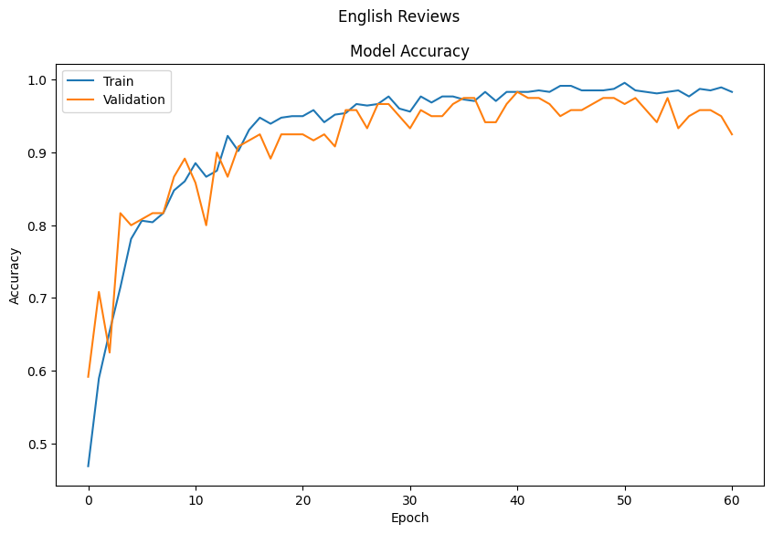

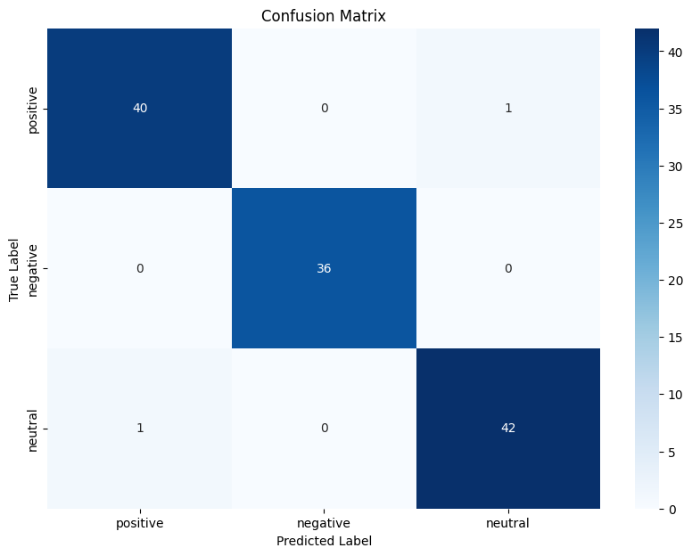

```
Test Accuracy: 0.9833
Error Rate: 0.0167
```

```python
# Set the seed for reproducibility
seed = 88
np.random.seed(seed)
tf.random.set_seed(seed)

# Creating a more complex model for English reviews
model = Sequential()
model.add(Embedding(len(english_word_index) + 1, english_embedding_dim, input_length=MAX_SEQUENCE_LENGTH, weights=[english_embedding_matrix], trainable=False))
model.add(LSTM(300, return_sequences=True, dropout=0.2, recurrent_dropout=0.2))
model.add(LSTM(100, dropout=0.2, recurrent_dropout=0.2))
model.add(Dense(64, activation='relu'))
model.add(Dropout(0.2))
model.add(Dense(3, activation='softmax'))

model.compile(loss='sparse_categorical_crossentropy', optimizer='adam', metrics=['accuracy'])
model.summary()

# Define early stopping callback
early_stopping = EarlyStopping(monitor='val_accuracy', patience=20, verbose=2, restore_best_weights=True)

# Fit the model with early stopping
history = model.fit(x_train, y_train, epochs=100, batch_size=64, validation_data=(x_test,y_test), callbacks=[early_stopping])

# Plot accuracy
plt.figure(figsize=(10, 6))
plt.suptitle('English Reviews')
plt.plot(history.history['accuracy'], label='Train')
plt.plot(history.history['val_accuracy'], label='Validation')
plt.title('Model Accuracy')
plt.ylabel('Accuracy')
plt.xlabel('Epoch')
plt.legend(loc='upper left')
plt.show()

# Predict the output on the test set
predictions = model.predict(x_test)
predicted_classes = np.argmax(predictions, axis=1)

# Get the true labels
true_classes = y_test

class_labels = list(labels_dict.keys())

# Compute the confusion matrix
cm = confusion_matrix(true_classes, predicted_classes)

# Plot confusion matrix
plot_confusion_matrix(cm, class_labels)

# Evaluate the model on the test set
test_loss, test_accuracy = model.evaluate(x_test, y_test)

# Print the test accuracy and error rate
print(f'Test Accuracy: {test_accuracy:.4f}')
print(f'Error Rate: {(1 - test_accuracy):.4f}')
```

```
WARNING:tensorflow:Layer lstm_8 will not use cuDNN kernels since it doesn't meet the criteria. It will use a generic GPU kernel as fallback when running on GPU.
WARNING:tensorflow:Layer lstm_9 will not use cuDNN kernels since it doesn't meet the criteria. It will use a generic GPU kernel as fallback when running on GPU.
Model: "sequential_4"
_________________________________________________________________
 Layer (type)                Output Shape              Param #
=================================================================
 embedding_4 (Embedding)     (None, 40, 300)           68400

 lstm_8 (LSTM)               (None, 40, 300)           721200

 lstm_9 (LSTM)               (None, 100)               160400

 dense_8 (Dense)             (None, 64)                6464

 dropout_4 (Dropout)         (None, 64)                0

 dense_9 (Dense)             (None, 3)                 195

=================================================================
Total params: 956,659
Trainable params: 888,259
Non-trainable params: 68,400
_________________________________________________________________
Epoch 54: early stopping
```

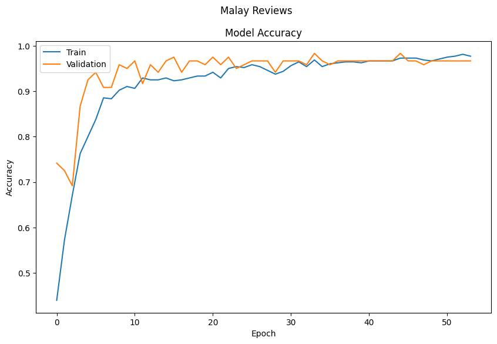

```
Test Accuracy: 0.9833
Error Rate: 0.0167
```

```python
# Set the seed for reproducibility
seed = 88
np.random.seed(seed)
tf.random.set_seed(seed)

# Creating a more complex model
model = Sequential()
model.add(Embedding(len(malay_word_index) + 1, malay_embedding_dim, input_length=MAX_SEQUENCE_LENGTH, weights=[malay_embedding_matrix], trainable=False))
model.add(LSTM(300, return_sequences=True, dropout=0.2, recurrent_dropout=0.2))
model.add(LSTM(100, dropout=0.2, recurrent_dropout=0.2))
model.add(Dense(64, activation='relu'))
model.add(Dropout(0.2))
model.add(Dense(3, activation='softmax'))

model.compile(loss='sparse_categorical_crossentropy', optimizer='adam', metrics=['accuracy'])
model.summary()

# Define early stopping callback
early_stopping = EarlyStopping(monitor='val_accuracy', patience=20, verbose=2, restore_best_weights=True)

# Fit the model with early stopping
history = model.fit(X_train, Y_train, epochs=100, batch_size=64, validation_data=(X_test,Y_test), callbacks=[early_stopping])

# Plot accuracy
plt.figure(figsize=(10, 6))
plt.suptitle('Malay Reviews')
plt.plot(history.history['accuracy'], label='Train')
plt.plot(history.history['val_accuracy'], label='Validation')
plt.title('Model Accuracy')
plt.ylabel('Accuracy')
plt.xlabel('Epoch')
plt.legend(loc='upper left')
plt.show()

# Predict the output on the test set
predictions = model.predict(X_test)
predicted_classes = np.argmax(predictions, axis=1)

# Get the true labels
true_classes = Y_test

class_labels = list(labels_dict.keys())

# Compute the confusion matrix
cm = confusion_matrix(true_classes, predicted_classes)

# Plot confusion matrix
plot_confusion_matrix(cm, class_labels)

# Evaluate the model on the test set
test_loss, test_accuracy = model.evaluate(X_test, Y_test)

# Print the test accuracy and error rate
print(f'Test Accuracy: {test_accuracy:.4f}')
print(f'Error Rate: {(1 - test_accuracy):.4f}')
```

[output not shown]

**Obversation:**

The test accuracy of the **Malay and English RNN improved** because the increased model complexity enabled the network to **capture and learn more intricate patterns and nuances** in the Malay dataset.

Hence, I would be using the **improved RNN model for hyperparameter tuning** as it has the better model performance.

### **Hyperparameter Tuning**

```
Reloading Tuner from keras_tuner_english_results\english_rnn_tuning\tuner0.json
WARNING:tensorflow:Layer lstm will not use cuDNN kernels since it doesn't meet the criteria. It will use a generic GPU kernel as fallback when running on GPU.
WARNING:tensorflow:Layer lstm_1 will not use cuDNN kernels since it doesn't meet the criteria. It will use a generic GPU kernel as fallback when running on GPU.
Test Accuracy: 0.9750
Error Rate: 0.0250
Best Hyperparameters:
dropout_1: 0.2
recurrent_dropout_1: 0.1
dropout_2: 0.2
recurrent_dropout_2: 0.1
dense_units: 64
dropout_dense: 0.2
optimizer: adam
WARNING:tensorflow:Layer lstm will not use cuDNN kernels since it doesn't meet the criteria. It will use a generic GPU kernel as fallback when running on GPU.
WARNING:tensorflow:Layer lstm_1 will not use cuDNN kernels since it doesn't meet the criteria. It will use a generic GPU kernel as fallback when running on GPU.
WARNING:tensorflow:Error in loading the saved optimizer state. As a result, your model is starting with a freshly initialized optimizer.
4/4 - 1s - 514ms/epoch - 128ms/step
```

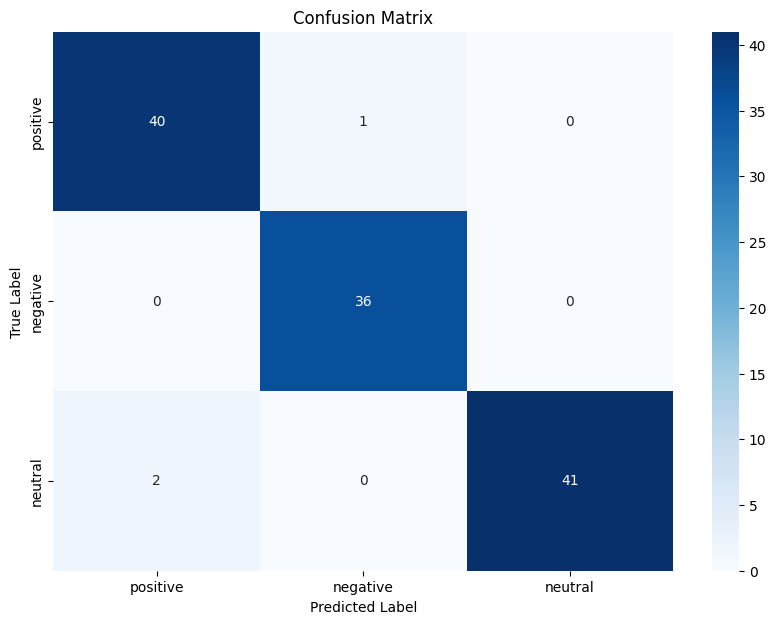

```python
# Define the function to create the Keras model with hyperparameters
def build_model(hp):
    model = Sequential([
        Embedding(len(english_word_index) + 1, english_embedding_dim, input_length=MAX_SEQUENCE_LENGTH, weights=[english_embedding_matrix], trainable=False),
        LSTM(300, return_sequences=True, dropout=hp.Float('dropout_1', 0.1, 0.3, step=0.1), recurrent_dropout=hp.Float('recurrent_dropout_1', 0.1, 0.3, step=0.1)),
        LSTM(100, dropout=hp.Float('dropout_2', 0.1, 0.3, step=0.1), recurrent_dropout=hp.Float('recurrent_dropout_2', 0.1, 0.3, step=0.1)),
        Dense(hp.Int('dense_units', 32, 128, step=32), activation='relu'),
        Dropout(hp.Float('dropout_dense', 0.1, 0.3, step=0.1)),
        Dense(3, activation='softmax')
    ])

    model.compile(optimizer=hp.Choice('optimizer', ['adam', 'rmsprop']),
                  loss='sparse_categorical_crossentropy',
                  metrics=['accuracy'])
    return model

# Initialize the Keras Tuner
tuner = RandomSearch(
    build_model,
    objective='val_accuracy',
    max_trials=8,
    executions_per_trial=1,
    directory='keras_tuner_english_results',
    project_name='english_rnn_tuning'
)

# Define early stopping callback
early_stopping = EarlyStopping(monitor='val_accuracy', patience=20, restore_best_weights=True, verbose=2)

# Perform hyperparameter tuning
tuner.search(x_train, y_train, epochs=100, validation_data=(x_test, y_test), callbacks=[early_stopping], verbose=2)

# Retrieve the best model
best_model = tuner.get_best_models(num_models=1)[0]

# Evaluate the best model on the test set
test_loss, test_accuracy = best_model.evaluate(x_test, y_test, verbose=1)
print(f'Test Accuracy: {test_accuracy:.4f}')
print(f'Error Rate: {(1 - test_accuracy):.4f}')

# Save the best model
best_model.save('./best_model/best_english_rnn_model.h5')

# Retrieve the best hyperparameters
best_hyperparameters = tuner.get_best_hyperparameters(num_trials=1)[0]

# Print the best hyperparameters
print("Best Hyperparameters:")
print(f"dropout_1: {best_hyperparameters.get('dropout_1')}")
print(f"recurrent_dropout_1: {best_hyperparameters.get('recurrent_dropout_1')}")
print(f"dropout_2: {best_hyperparameters.get('dropout_2')}")
print(f"recurrent_dropout_2: {best_hyperparameters.get('recurrent_dropout_2')}")
print(f"dense_units: {best_hyperparameters.get('dense_units')}")
print(f"dropout_dense: {best_hyperparameters.get('dropout_dense')}")
print(f"optimizer: {best_hyperparameters.get('optimizer')}")

# Load the best model for predictions
best_model = load_model('./best_model/best_english_rnn_model.h5')

# Predict the output on the test set
predictions = best_model.predict(x_test, verbose=2)
predicted_classes = np.argmax(predictions, axis=1)

# Get the true labels
true_classes = y_test
class_labels = list(labels_dict.keys())

# Compute the confusion matrix
cm = confusion_matrix(true_classes, predicted_classes)

plot_confusion_matrix(cm, class_labels)
```

```python
# Define the function to create the Keras model with hyperparameters
def build_model(hp):
    model = Sequential([
        Embedding(len(malay_word_index) + 1, malay_embedding_dim, input_length=MAX_SEQUENCE_LENGTH, weights=[malay_embedding_matrix], trainable=False),
        LSTM(300, return_sequences=True, dropout=hp.Float('dropout_1', 0.1, 0.3, step=0.1), recurrent_dropout=hp.Float('recurrent_dropout_1', 0.1, 0.3, step=0.1)),
        LSTM(100, dropout=hp.Float('dropout_2', 0.1, 0.3, step=0.1), recurrent_dropout=hp.Float('recurrent_dropout_2', 0.1, 0.3, step=0.1)),
        Dense(hp.Int('dense_units', 32, 128, step=32), activation='relu'),
        Dropout(hp.Float('dropout_dense', 0.1, 0.3, step=0.1)),
        Dense(3, activation='softmax')
    ])

    model.compile(optimizer=hp.Choice('optimizer', ['adam', 'rmsprop']),
                  loss='sparse_categorical_crossentropy',
                  metrics=['accuracy'])
    return model

# Initialize the Keras Tuner
tuner = RandomSearch(
    build_model,
    objective='val_accuracy',
    max_trials=8,
    executions_per_trial=1,
    directory='keras_tuner_malay_results',
    project_name='malay_rnn_tuning'
)

# Define early stopping callback
early_stopping = EarlyStopping(monitor='val_accuracy', patience=20, restore_best_weights=True, verbose=2)

# Perform hyperparameter tuning
tuner.search(X_train, Y_train, epochs=100, validation_data=(X_test, Y_test), callbacks=[early_stopping], verbose=2)

# Retrieve the best model
best_model = tuner.get_best_models(num_models=1)[0]

# Evaluate the best model on the test set
test_loss, test_accuracy = best_model.evaluate(X_test, Y_test, verbose=1)
print(f'Test Accuracy: {test_accuracy:.4f}')
print(f'Error Rate: {(1 - test_accuracy):.4f}')

# Save the best model
best_model.save('./best_model/best_malay_rnn_model.h5')

# Retrieve the best hyperparameters
best_hyperparameters = tuner.get_best_hyperparameters(num_trials=1)[0]

# Print the best hyperparameters
print("Best Hyperparameters:")
print(f"dropout_1: {best_hyperparameters.get('dropout_1')}")
print(f"recurrent_dropout_1: {best_hyperparameters.get('recurrent_dropout_1')}")
print(f"dropout_2: {best_hyperparameters.get('dropout_2')}")
print(f"recurrent_dropout_2: {best_hyperparameters.get('recurrent_dropout_2')}")
print(f"dense_units: {best_hyperparameters.get('dense_units')}")
print(f"dropout_dense: {best_hyperparameters.get('dropout_dense')}")
print(f"optimizer: {best_hyperparameters.get('optimizer')}")

# Load the best model for predictions
best_model = load_model('./best_model/best_malay_rnn_model.h5')

# Predict the output on the test set
predictions = best_model.predict(X_test)
predicted_classes = np.argmax(predictions, axis=1)

# Get the true labels
true_classes = Y_test
class_labels = list(labels_dict.keys())

# Compute the confusion matrix
cm = confusion_matrix(true_classes, predicted_classes)

plot_confusion_matrix(cm, class_labels)
```

[output not shown]

```
Trial 8 Complete [00h 03m 31s]
val_accuracy: 0.9750000238418579

Best val_accuracy So Far: 0.9833333492279053
Total elapsed time: 06h 00m 41s
WARNING:tensorflow:Layer lstm will not use cuDNN kernels since it doesn't meet the criteria. It will use a generic GPU kernel as fallback when running on GPU.
WARNING:tensorflow:Layer lstm_1 will not use cuDNN kernels since it doesn't meet the criteria. It will use a generic GPU kernel as fallback when running on GPU.
Test Accuracy: 0.9833
Error Rate: 0.0167
Best Hyperparameters:
dropout_1: 0.2
recurrent_dropout_1: 0.2
dropout_2: 0.1
recurrent_dropout_2: 0.1
dense_units: 96
dropout_dense: 0.1
optimizer: adam
WARNING:tensorflow:Layer lstm will not use cuDNN kernels since it doesn't meet the criteria. It will use a generic GPU kernel as fallback when running on GPU.
WARNING:tensorflow:Layer lstm_1 will not use cuDNN kernels since it doesn't meet the criteria. It will use a generic GPU kernel as fallback when running on GPU.
WARNING:tensorflow:Error in loading the saved optimizer state. As a result, your model is starting with a freshly initialized optimizer.
```

### Loading Best Models with Hyperparameter Tuning

```
WARNING:tensorflow:Layer lstm will not use cuDNN kernels since it doesn't meet the criteria. It will use a generic GPU kernel as fallback when running on GPU.
WARNING:tensorflow:Layer lstm_1 will not use cuDNN kernels since it doesn't meet the criteria. It will use a generic GPU kernel as fallback when running on GPU.
WARNING:tensorflow:Error in loading the saved optimizer state. As a result, your model is starting with a freshly initialized optimizer.
Epoch 98: early stopping
```

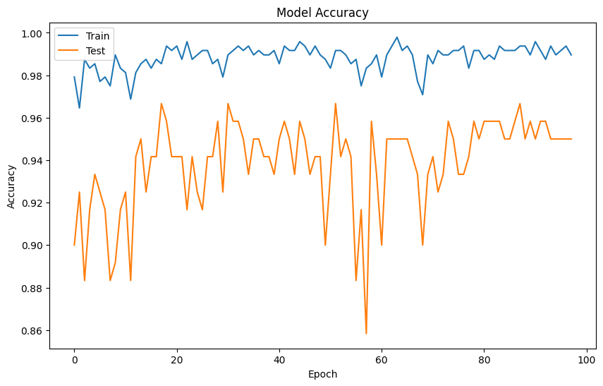

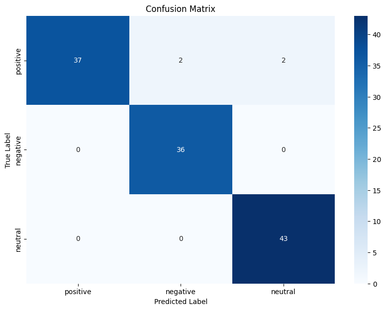

```
Test Accuracy: 0.9667
Error Rate: 0.0333
```

```python
# Set the seed for reproducibility
seed = 88
np.random.seed(seed)
tf.random.set_seed(seed)

# Load the best model
best_model_english = load_model('./best_model/best_english_rnn_model.h5')

# Define early stopping callback
early_stopping = EarlyStopping(monitor='val_accuracy', patience=80, restore_best_weights=True, verbose=2)

# Fit the model with early stopping
history = best_model_english.fit(x_train, y_train, epochs=100, validation_data=(x_test, y_test), callbacks=[early_stopping])

# Plot accuracy
plt.figure(figsize=(10, 6))
plt.plot(history.history['accuracy'], label='Train')
plt.plot(history.history['val_accuracy'], label='Test')
plt.title('Model Accuracy')
plt.ylabel('Accuracy')
plt.xlabel('Epoch')
plt.legend(loc='upper left')
plt.show()

# Predict the output on the test set
predictions = best_model_english.predict(x_test)
predicted_classes = np.argmax(predictions, axis=1)

# Get the true labels
true_classes = y_test

# Define class labels
class_labels = list(labels_dict.keys())

# Compute the confusion matrix
cm = confusion_matrix(true_classes, predicted_classes)

# Plot confusion matrix
plot_confusion_matrix(cm, class_labels)

# Evaluate the model on the test set
test_loss, test_accuracy = best_model_english.evaluate(x_test, y_test)

# Print the test accuracy and error rate
print(f'Test Accuracy: {test_accuracy:.4f}')
print(f'Error Rate: {(1 - test_accuracy):.4f}')
```

```
WARNING:tensorflow:Layer lstm will not use cuDNN kernels since it doesn't meet the criteria. It will use a generic GPU kernel as fallback when running on GPU.
WARNING:tensorflow:Layer lstm_1 will not use cuDNN kernels since it doesn't meet the criteria. It will use a generic GPU kernel as fallback when running on GPU.
WARNING:tensorflow:Error in loading the saved optimizer state. As a result, your model is starting with a freshly initialized optimizer.
Epoch 23: early stopping
```

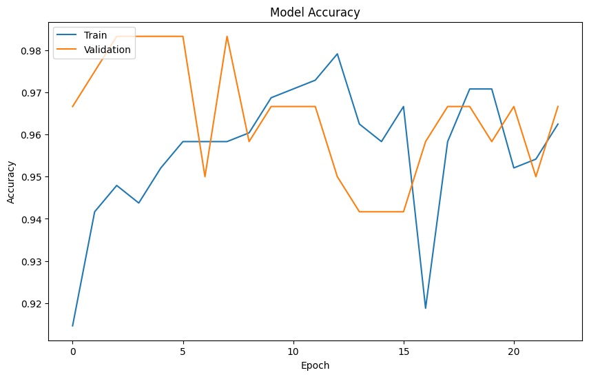

```
Test Accuracy: 0.9833
Error Rate: 0.0167
```

```python
# Set the seed for reproducibility
seed = 88
np.random.seed(seed)
tf.random.set_seed(seed)

# Load the best model for the Malay dataset
best_model_malay = load_model('./best_model/best_malay_rnn_model.h5')

# Define early stopping callback
early_stopping = EarlyStopping(monitor='val_accuracy', patience=20, restore_best_weights=True, verbose=2)

# Fit the model with early stopping
history = best_model_malay.fit(X_train, Y_train, epochs=100, validation_data=(X_test,Y_test), callbacks=[early_stopping])

# Plot accuracy
plt.figure(figsize=(10, 6))
plt.plot(history.history['accuracy'], label='Train')
plt.plot(history.history['val_accuracy'], label='Validation')
plt.title('Model Accuracy')
plt.ylabel('Accuracy')
plt.xlabel('Epoch')
plt.legend(loc='upper left')
plt.show()

# Predict the output on the test set
predictions = best_model_malay.predict(X_test)
predicted_classes = np.argmax(predictions, axis=1)

# Get the true labels
true_classes = Y_test

# Define class labels
class_labels = list(labels_dict.keys())  # Ensure labels_dict contains the correct labels for the Malay dataset

# Compute the confusion matrix
cm = confusion_matrix(true_classes, predicted_classes)

# Plot confusion matrix
plot_confusion_matrix(cm, class_labels)

# Evaluate the model on the test set
test_loss, test_accuracy = best_model_malay.evaluate(X_test, Y_test)

# Print the test accuracy and error rate
print(f'Test Accuracy: {test_accuracy:.4f}')
print(f'Error Rate: {(1 - test_accuracy):.4f}')
```

[output not shown]

```python
# Function to preprocess the review
def preprocess_review(review, word_index, max_sequence_length):
    tokens = review.split()  # Tokenize the review
    sequences = [word_index.get(token, 0) for token in tokens]  # Convert tokens to integers
    padded_sequence = pad_sequences([sequences], maxlen=max_sequence_length, padding='post')
    return padded_sequence

new_review = "This movie was fantastic and thrilling!"
preprocessed_review = preprocess_review(new_review, english_word_index, MAX_SEQUENCE_LENGTH)

# Predict the sentiment
predictions = best_model_english.predict(preprocessed_review)
predicted_class = np.argmax(predictions, axis=1)[0]

class_labels = {0: 'Negative', 1: 'Neutral', 2: 'Positive'}

predicted_sentiment = class_labels[predicted_class]
print(f"Predicted Sentiment: {predicted_sentiment}")
```

```
Predicted Sentiment: Positive
```

```python
# Load the saved model
model = load_model('./best_model/best_malay_rnn_model.h5')

# Function to preprocess the review
def preprocess_review(review, word_index, max_sequence_length):
    tokens = review.split()  # Tokenize the review
    sequences = [word_index.get(token, 0) for token in tokens]  # Convert tokens to integers
    padded_sequence = pad_sequences([sequences], maxlen=max_sequence_length, padding='post')
    return padded_sequence

# "It is just an ordinary movie, nothing special."
new_review =   "Ia adalah filem yang biasa-biasa sahaja, tidak istimewa."
preprocessed_review = preprocess_review(new_review, malay_word_index, MAX_SEQUENCE_LENGTH)

# Predict the sentiment
predictions = best_model_malay.predict(preprocessed_review)
predicted_class = np.argmax(predictions, axis=1)[0]

# Define the class labels (match these with your training labels)
class_labels = {0: 'Negative', 1: 'Neutral', 2: 'Positive'}

predicted_sentiment = class_labels[predicted_class]
print(f"Predicted Sentiment: {predicted_sentiment}")
```

```
WARNING:tensorflow:Layer lstm will not use cuDNN kernels since it doesn't meet the criteria. It will use a generic GPU kernel as fallback when running on GPU.
WARNING:tensorflow:Layer lstm_1 will not use cuDNN kernels since it doesn't meet the criteria. It will use a generic GPU kernel as fallback when running on GPU.
WARNING:tensorflow:Error in loading the saved optimizer state. As a result, your model is starting with a freshly initialized optimizer.
Predicted Sentiment: Neutral
```